# Infection Intensity Data Analysis

```r
######
#how are the zeros captured by the models?
#gc() #clear memory to make space for computation

#zinb_predictions <- predict(z3, type = "prob") #even more computationally intensive - too large to process in R alone

#str(zinb_predictions)
#summary(zinb_predictions)
#as.data.frame(zinb_predictions)

observed_zeros <- round(sum(II_Data$CFUs < 1))
Pois_zeros <- round(sum(dpois(0, fitted(glmPoisson))))
NegBin_zeros <- round(sum(dnbinom(0, mu = fitted(glmNegBinomial), size = glmNegBinomial$theta)))
#zinb_zeros <- round(sum(zinb_predictions[,1])) #=22
zinb_zeros <- 22

comparing_zeros <- c("Obs"=observed_zeros,"ML-Pois"=Pois_zeros,"NB"=NegBin_zeros,"ZINB"=zinb_zeros)
comparing_zeros
```

```
##     Obs ML-Pois      NB    ZINB
##      22       0       0      22
```

```r
#expected mean counts:
mu_zinb <- predict(z3, type="response")
head(mu_zinb)
```

```
##        1        2        3        4        5        6
## 24433.75 24433.75 24433.75 24433.75 24433.75 24433.75
```

```r
#zero-inflated negative binomial model is best fit

#check the dispersion statistic:
E2 <- resid(z3, type = "pearson")
N  <- nrow(II_Data)
p  <- length(coef(z3)) + 1  # '+1' is for variance in NB model
sum(E2^2) / (N - p)
```

```
## [1] 1.015009
```

```r
# = 1.015009, close to 1 = good
#closer to 1 than the negative binomial model



#are the z3 model parameters important? yes.
library(car)
Anova(z3,
      type="II",
      test="Chisq")
```

```
## Analysis of Deviance Table (Type II tests)
##
## Response: CFUs
##                 Df   Chisq Pr(>Chisq)
## Temperature      1 835.375  < 2.2e-16 ***
## Age              1 299.670  < 2.2e-16 ***
## Temperature:Age  1  15.017  0.0001065 ***
## ---
## Signif. codes:  0 '***' 0.001 '**' 0.01 '*' 0.05 '.' 0.1 ' ' 1
```

```r
#is z3 model better than the null zi model?
library(rcompanion)
nagelkerke(z3) #yes
```

```
## $Models
##
## Model: "zeroinfl, CFUs ~ Temperature * Age | 1, II_Data, negbin"
## Null:  "zeroinfl, CFUs ~ 1, II_Data, negbin"
##
## $Pseudo.R.squared.for.model.vs.null
##                              Pseudo.R.squared
## McFadden                            0.0311824
## Cox and Snell (ML)                  0.5770930
## Nagelkerke (Cragg and Uhler)        0.5770930
##
## $Likelihood.ratio.test
##  Df.diff LogLik.diff  Chisq     p.value
##       -3     -299.49 598.98 1.6767e-129
##
## $Number.of.observations
##
## Model: 696
## Null:  696
##
## $Messages
## [1] "Note: For models fit with REML, these statistics are based on refitting with ML"
##
## $Warnings
## [1] "None"
```

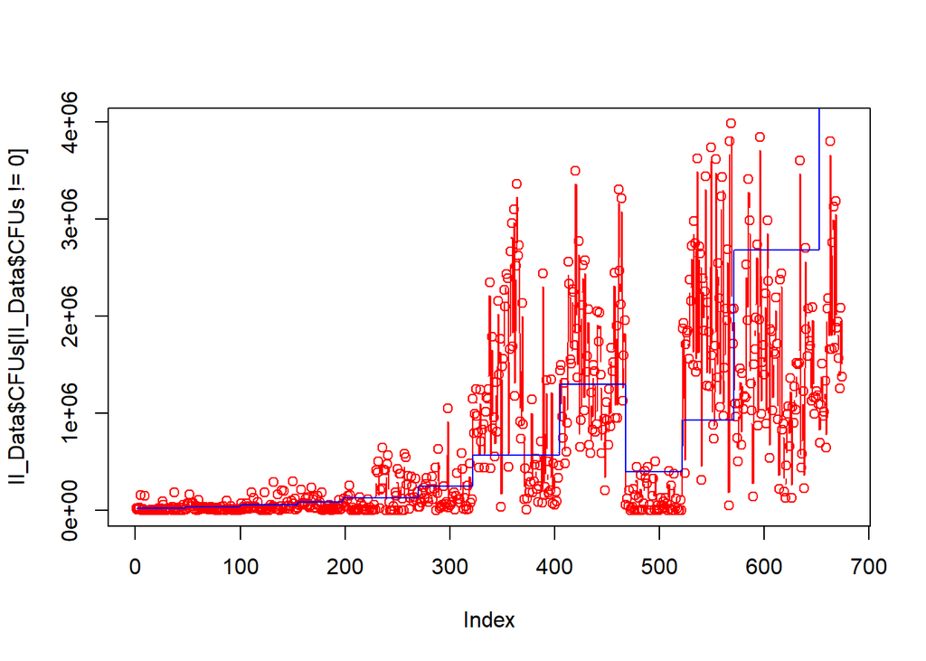

## Model Interpretation and Visualization

```r
summary(z3)
```

```
##
## Call:
## zeroinfl(formula = CFUs ~ Temperature * Age | 1, data = II_Data, dist = "negbin")
##
## Pearson residuals:
##     Min      1Q  Median      3Q     Max
## -0.8665 -0.6830 -0.3692  0.3006  5.8005
##
## Count model coefficients (negbin with log link):
##                  Estimate Std. Error z value Pr(>|z|)
## (Intercept)     -4.364214   1.443458  -3.023 0.002499 **
## Temperature      0.533625   0.048530  10.996  < 2e-16 ***
## Age             -0.556265   0.185236  -3.003 0.002673 **
## Temperature:Age  0.024016   0.006197   3.875 0.000107 ***
## Log(theta)      -0.229650   0.049360  -4.653 3.28e-06 ***
##
## Zero-inflation model coefficients (binomial with logit link):
##             Estimate Std. Error z value Pr(>|z|)
## (Intercept)  -3.4222     0.2169  -15.78   <2e-16 ***
## ---
## Signif. codes:  0 '***' 0.001 '**' 0.01 '*' 0.05 '.' 0.1 ' ' 1
##
## Theta = 0.7948
## Number of iterations in BFGS optimization: 1
## Log-likelihood: -9305 on 6 Df
```

### Model Interpretation:

For the count model (non-zero), Temperature, Age, and the Temperature*Age Interaction are all significant predictors of the log(CFUs) The estimate for temperature is 0.533625. This means that for each one unit increase in temperature, the expected change in log(CFUs) is 0.533625, holding all other variables constant. With increasing temperature, the log(CFUs) increases. The estimate for age is -0.556265. For each one unit increase in age, the expected change in log(CFUs) is -0.556265, holding all other variables constant.

The interaction term is also significant. Temp has a greater part of this.

Theta equals the inverse of the dispersion parameter.

Baseline risk count being an excessive zero (zero inflation model) is small exp(-3.4222).

## Model Predictions: Confidence Intervals and Risk/Odds Ratios

```r
#now, use bootstrapping to find confidence intervals and
#also to determine risk/odd ratios for the parameter estimates

library(boot)
#get start values for each part of the model:
dput(round(coef(z3, "count"), 4))
```

```
## c(`(Intercept)` = -4.3642, Temperature = 0.5336, Age = -0.5563,
## `Temperature:Age` = 0.024)
```

```r
dput(round(coef(z3, "zero"), 4))
```

```
## c(`(Intercept)` = -3.4222)
```

```r
#put these values into the following equation in the function f:
f <- function(data, i) {
  require(pscl)
  z3 <- zeroinfl(CFUs ~ Temperature*Age | 1,
                 dist = 'negbin',
                 data = data[i,],
                 start = list(count = c(-4.3642, 0.5336,-0.5563,0.024),
                              zero = c(-3.4222)))
  as.vector(t(do.call(rbind, coef(summary(z3)))[, 1:2]))
}

#bootstrap:
set.seed(10)
(res <- boot(II_Data, f, R = 1200, parallel = "snow", ncpus = 4))
```

```
##
## ORDINARY NONPARAMETRIC BOOTSTRAP
##
##
## Call:
## boot(data = II_Data, statistic = f, R = 1200, parallel = "snow",
##     ncpus = 4)
##
##
## Bootstrap Statistics :
##          original        bias     std. error
## t1*  -4.362934301 -2.131647e-01 1.6996852777
## t2*   1.443454844  1.005890e-02 0.0870749056
## t3*   0.533578637  6.816668e-03 0.0570060772
## t4*   0.048529646  3.217878e-04 0.0027994386
## t5*  -0.556310448  1.985539e-02 0.1965529200
## t6*   0.185241690  1.089210e-03 0.0102338043
## t7*   0.024018151 -6.423144e-04 0.0066418209
## t8*   0.006197558  3.437818e-05 0.0003263984
## t9*  -0.229689249  6.967710e-03 0.0475507491
## t10*  0.049360759  1.185814e-04 0.0005404710
## t11* -3.424425684 -2.627736e-02 0.2304938181
## t12*  0.217124034  4.209042e-03 0.0247756136
```

```r
#the results alternate the coefficient estimates and their standard errors
#e.g. t1 is the estimate for the intercept in the conditional model, and t2 is the estimate for its standard error
```

```r
## basic parameter estimates with percentile and bias adjusted CIs
#use sapply to extract the parameter estimates and apply function:
parms <- t(sapply(c(1, 3, 5, 9, 11), function(i) {
  out <- boot.ci(res, index = c(i, i + 1), type = c("perc", "bca"))
  with(out, c(Est = t0, pLL = percent[4], pUL = percent[5],
              bcaLL = bca[4], bcaUL = bca[5]))
}))

## add row names
as.data.frame(parms)
```

```
##          Est        pLL        pUL      bcaLL      bcaUL
## 1 -4.3629343 -8.0917486 -1.2413193 -7.3938263 -0.6959797
## 2  0.5335786  0.4292336  0.6589985  0.4110071  0.6346642
## 3 -0.5563104 -0.9205017 -0.1399576 -0.9756443 -0.1862490
## 4 -0.2296892 -0.3124554 -0.1258011 -0.3256091 -0.1403891
## 5 -3.4244257 -3.9653239 -3.0331658 -3.8896745 -2.9711782
```

```r
row.names(parms) <- names(coef(z3))

## print results for confidence intervals:
parms
```

[output not shown]

```r
## compare with normal based approximation
confint(z3) # bootstrapped errors should be larger
```

```
##                             2.5 %      97.5 %
## count_(Intercept)     -7.19333908 -1.53508955
## count_Temperature      0.43850826  0.62874219
## count_Age             -0.91932160 -0.19320869
## count_Temperature:Age  0.01186957  0.03616292
## zero_(Intercept)      -3.84729479 -2.99708053
```

```r
#now, follow similar procedure - exponentiate estimates (using log)
#get incident risk ratio (IRR) for negative binomial model (non-zeros)
#get odds ratio (OR) for logit model (zero component) (zero inflation model)

## exponentiated parameter estimates with percentile and bias adjusted CIs
expparms <- t(sapply(c(1, 3, 5, 7, 9), function(i) {
  out <- boot.ci(res, index = c(i, i + 1), type = c("perc", "bca"), h = exp)
  with(out, c(Est = t0, pLL = percent[4], pUL = percent[5],
              bcaLL = bca[4], bcaUL = bca[5]))
}))


## add row names
as.data.frame(expparms)
```

```
##          Est          pLL       pUL        bcaLL     bcaUL
## 1 0.01274095 0.0003060547 0.2890040 0.0006150381 0.4985858
## 2 1.70502306 1.5360798768 1.9328556 1.5083360055 1.8863885
## 3 0.57332046 0.3983191630 0.8693951 0.3769494120 0.8300669
## 4 1.02430891 1.0101423140 1.0369178 1.0115798085 1.0387796
## 5 0.79478054 0.7316482849 0.8817902 0.7220873643 0.8690200
```

```r
row.names(expparms) <- names(coef(z3))
## print results
expparms
```

[output not shown]

We can create risk and odds ratios because the parameter is the log of the ratio of expected counts (due to the distribution) (see https://stats.oarc.ucla.edu/r/dae/negative-binomial-regression/)

```r
newdata1 <- expand.grid(c(27,30,32), rep(c(1,5,10,15)))


colnames(newdata1) <- c("Temperature", "Age")
newdata1$phat <- predict(z3, newdata1)
#newdata1$phatlog <- log(newdata1$phat)

newdata1
```

```
##    Temperature Age       phat
## 1           27   1   24433.75
## 2           30   1  130176.32
## 3           32   1  397093.90
## 4           27   5   35327.42
## 5           30   5  251081.81
## 6           32   5  928148.51
## 7           27  10   56009.82
## 8           30  10  570715.08
## 9           32  10 2682395.40
## 10          27  15   88800.71
## 11          30  15 1297249.28
## 12          32  15 7752256.24
```

```r
II_Summary <- II_Data %>%
  group_by(Temperature,Age) %>%
  summarise(mean_CFUs = mean(CFUs),
            median_CFUs = median(CFUs),
            sd_CFUs = sd(CFUs),
            n_CFUs = n(),
            SE_CFUs = sd(CFUs)/sqrt(n()))
```

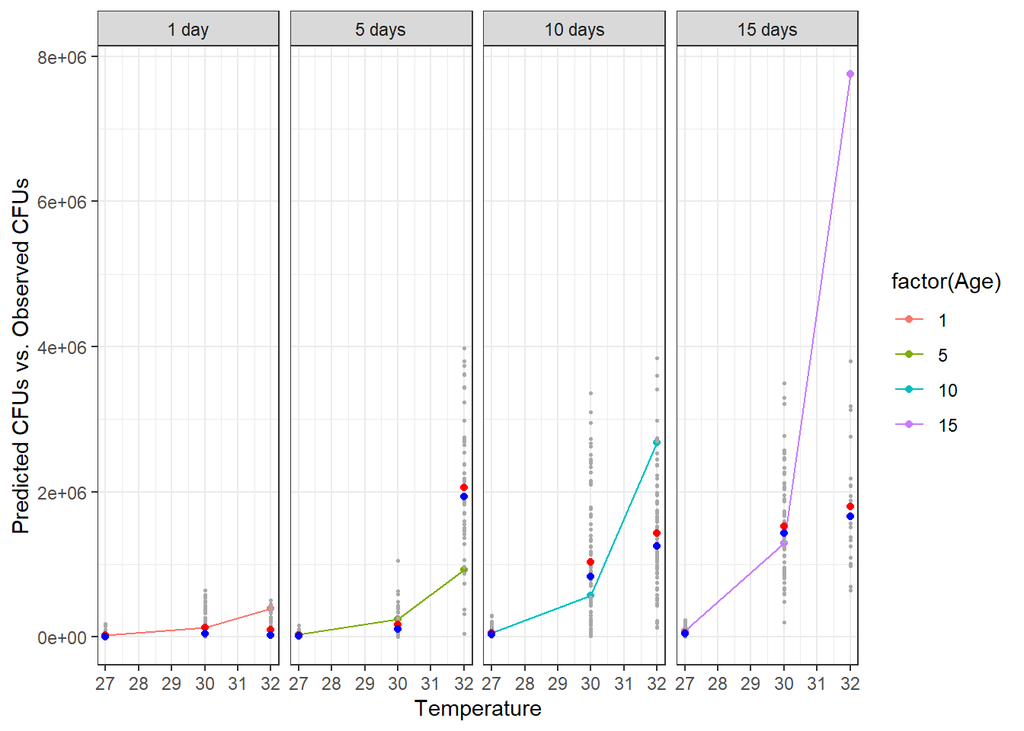

```r
ggplot(newdata1, aes(x = Temperature, y = phat, colour = factor(Age))) +
  geom_point() +
  geom_line() +
  facet_grid(~Age,labeller = labeller(Age=agelabs, Temperature=templabs)) +
  labs(x = "Temperature", y = "Predicted CFUs vs. Observed CFUs")+
  geom_point(aes(x=Temperature,y=CFUs),size=(0.5),color="dark gray",data=II_Data)+
  geom_point(aes(x=Temperature,y=mean_CFUs),color="red",data=II_Summary)+
  geom_point(aes(x=Temperature,y=median_CFUs),color="blue",data=II_Summary)+
  #geom_errorbar(aes(ymin=predFE.min, ymax=predFE.max)) +
  theme_bw()
```